# Client Report - Further Housing Data Analysis

- Show All Code
- Hide All Code

Housing and Student Living Office

Author

Kayson Garn

# Explorative Housing Analysis

# Exploring Complex Sizes

```r
#to read in the data
HSL_data <- rio::import("HSL_data.csv")
```

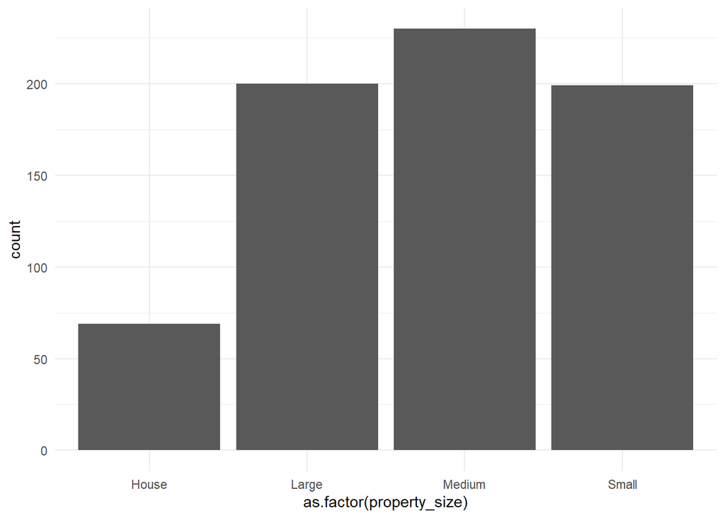

```r
#to investigate what bins should be created...
HSL_data <- HSL_data |>
  mutate(property_size  = case_when(
    Total_Beds < 20 ~ "House",
    Total_Beds >=20 & Total_Beds <80 ~ "Small",
    Total_Beds >=80 & Total_Beds <=180 ~ "Medium",
    Total_Beds >180 ~ "Large"
  ))


hist_bins <- ggplot(HSL_data, aes(x=as.factor(property_size))) + geom_bar() + theme_minimal()

hist_bins
```

So we define the following

**House:** **x** < 20

**Small:** 20 <= **x** < 80

**Medium**: 80 <= **x** <= 180

**Large**: **x** > 180

Lets Look at the differences in prices compared to the different sized apartment complexes.

### Original Price Comparison

```r
HSL_years_high_occ_grouped <- HSL_data |>
  filter(!is.na(Cleanliness)) |>
  group_by(Semester, Year, Full_Occ) |>
  summarise(
    mean_price = mean(Mean_Contract_Price),
    median_occ = median(Occ_Rate) * 100,
    mean_beds = mean(Total_Beds),
    mean_management = mean(Management),
    mean_maintenance = mean(Maintenance_Response),
    mean_cleanliness = mean(Cleanliness),
    mean_activities = mean(Activities_Events),
    mean_culture = mean(Culture),
    mean_value = mean(Value),
    mean_overall = mean(Overall)
  ) |>
  mutate(
    Semester = case_when(
      Semester == "SP" ~ "Spring",
      Semester == "WI" ~ "Winter"
    )
  )
```

```r
price_chart <- ggplot(HSL_years_high_occ_grouped,
                      aes(x = Year, y = mean_price, color = Full_Occ)) +
  geom_line(linewidth = 1.2) +
  geom_point(size = 3) +
  facet_wrap(~Semester) +
  scale_color_manual(
    values = c(
      "TRUE" = "#006EB6",
      "FALSE" = "#949598"
    )
  ) +
  theme_minimal() +
  theme(
    strip.text = element_text(face = "bold"),
    plot.title = element_text(size = 16, face = "bold"),
    panel.spacing = unit(1.5, "lines")
  ) +
  labs(
    title = "Student Approved Housing 2022-2025",
    x = "Year",
    y = "Mean Price",
    color = "Full Occupancy"
  )

ggplotly(price_chart)
```

[interactive chart not shown]

This visual represents the aggregate of all properties sizes grouped by “full” and “non-full” occupancy and split by semester.

### Price Comparison by Property Size

```r
HSL_size_spring <- HSL_data |>
  filter(!is.na(Cleanliness)) |>
  group_by(Semester, Year, Full_Occ, property_size) |>
  summarise(
    mean_price = mean(Mean_Contract_Price),
    median_occ = median(Occ_Rate) * 100,
    mean_beds = mean(Total_Beds),
    mean_management = mean(Management),
    mean_maintenance = mean(Maintenance_Response),
    mean_cleanliness = mean(Cleanliness),
    mean_activities = mean(Activities_Events),
    mean_culture = mean(Culture),
    mean_value = mean(Value),
    mean_overall = mean(Overall)
  ) |>
  mutate(
    Semester = case_when(
      Semester == "SP" ~ "Spring",
      Semester == "WI" ~ "Winter"
    )
  ) |>
    filter(Semester == "Spring")
```

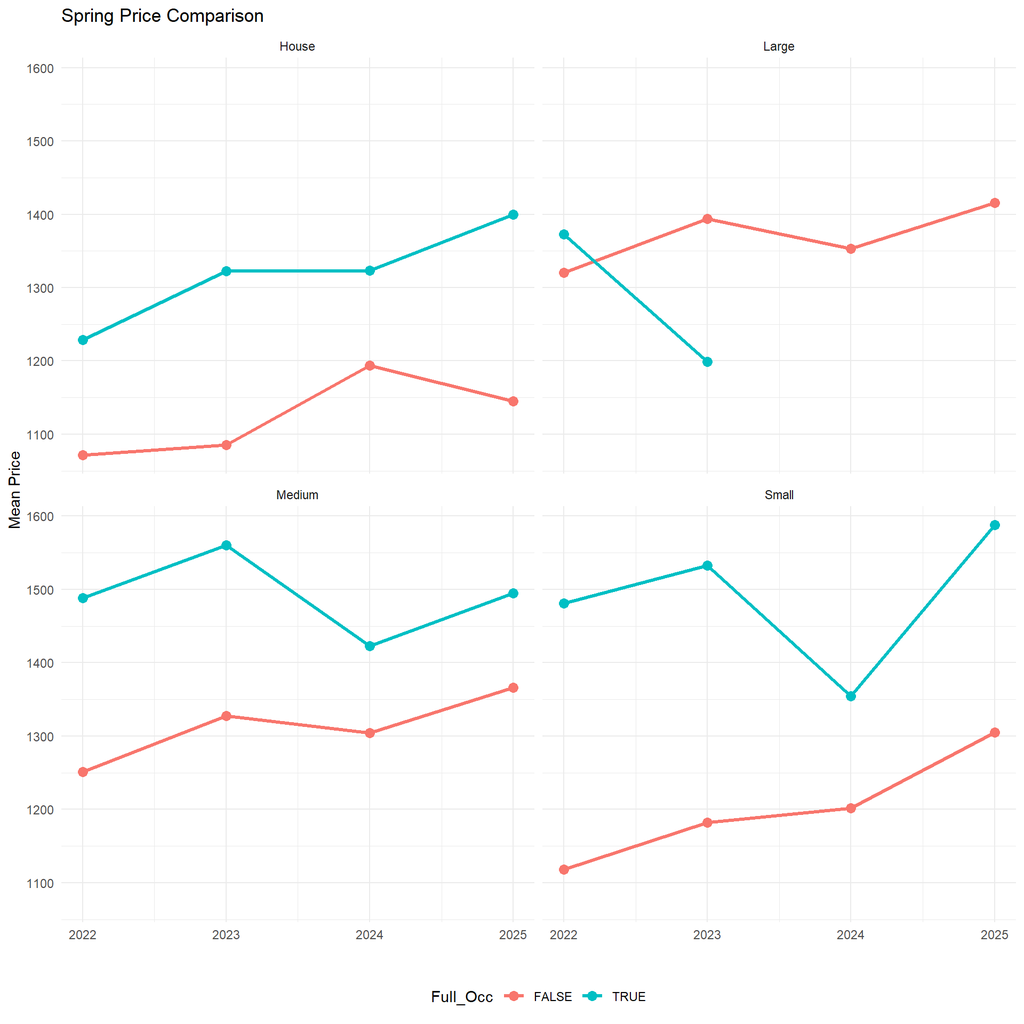

```r
price_chart_spring <- ggplot(HSL_size_spring,
                      aes(x = Year, y = mean_price, color = Full_Occ)) +
  geom_line(linewidth = 1.2) +
  geom_point(size = 3) +
  facet_wrap(~property_size) +
  theme_minimal() +
  labs(
    y= "Mean Price",
    x=" ",
    title="Spring Price Comparison"
  ) +
  theme(
    legend.position = "bottom"
  )

price_chart_spring
```

Across all property sizes except for the large apartment complexes, those properties that tend to be full during the Spring semester. The large properties tend to have greater difficulty in filling for the Spring and during 2024 and 2025 had no properties with full occupancy rates. Thus we can observe that for this particular type of property, student’s may may be given an incentive to live in larger apartment complexes through a mix of lowering contract prices and increasing property quality through increased investment in maintenance, cleanliness, and management..

```r
HSL_size_winter <- HSL_data |>
  filter(!is.na(Cleanliness)) |>
  group_by(Semester, Year, Full_Occ, property_size) |>
  summarise(
    mean_price = mean(Mean_Contract_Price),
    median_occ = median(Occ_Rate) * 100,
    mean_beds = mean(Total_Beds),
    mean_management = mean(Management),
    mean_maintenance = mean(Maintenance_Response),
    mean_cleanliness = mean(Cleanliness),
    mean_activities = mean(Activities_Events),
    mean_culture = mean(Culture),
    mean_value = mean(Value),
    mean_overall = mean(Overall)
  ) |>
  mutate(
    Semester = case_when(
      Semester == "SP" ~ "Spring",
      Semester == "WI" ~ "Winter"
    )
  ) |>
    filter(Semester == "Winter")
```

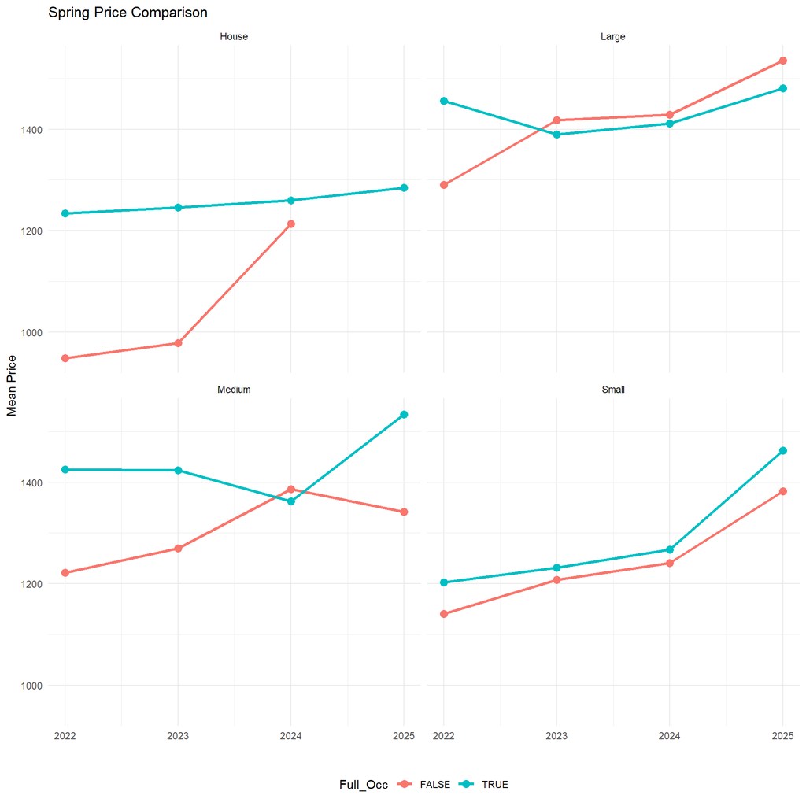

```r
price_chart_winter <- ggplot(HSL_size_winter,
                      aes(x = Year, y = mean_price, color = Full_Occ)) +
  geom_line(linewidth = 1.2) +
  geom_point(size = 3) +
  facet_wrap(~property_size) +
  theme_minimal() +
  labs(
    y= "Mean Price",
    x=" ",
    title="Spring Price Comparison"
  ) +
  theme(
    legend.position = "bottom"
  )

price_chart_winter
```

In exploring the pricing trends grouped by property size we can observe that while greater demand is introduced into the market the differences in price between those properties that are full and those that are not are mush closer when compared to Spring results.

### Original Occupancy Comparison

```r
occ_chart <- ggplot(HSL_years_high_occ_grouped, aes(x=Year, y=median_occ, color= Full_Occ)) +
  geom_line(size = 1.2) +
  geom_point(size = 3) +
  facet_wrap(~Semester) +
  scale_color_manual(
    values = c(
      "TRUE" = "#006EB6",
      "FALSE" = "#949598"
    )) +
  theme_minimal() +
  theme(
    strip.text = element_text(face = "bold"),
    plot.title = element_text(size = 16, face = "bold"),
    panel.spacing = unit(1.5, "lines")
  ) +
  labs(
    title = "Student Approved Housing 2022-2025",
    x = "Year",
    y = "Mean Occupancy",
    color = "Full Occupancy"
  )

ggplotly(occ_chart)
```

[interactive chart not shown]

### Occupancy Comparison by Property Size

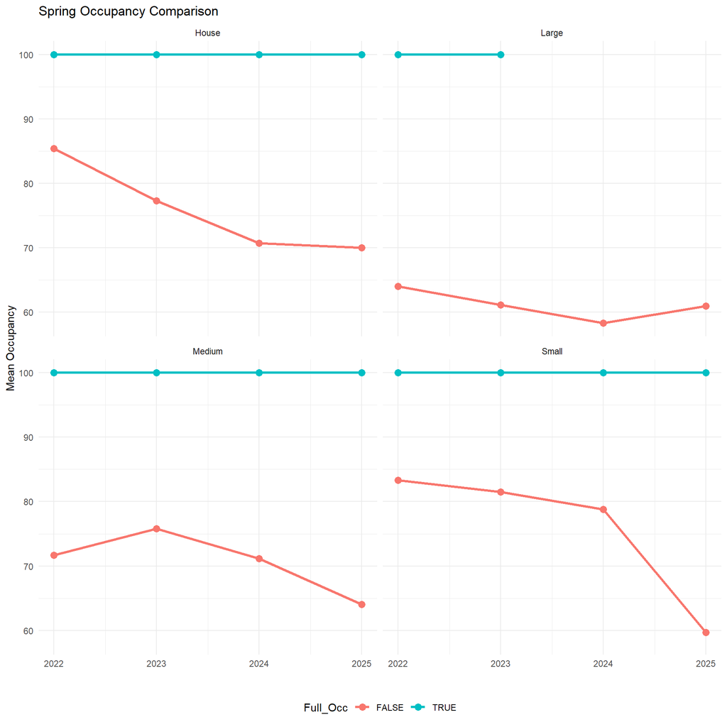

```r
occ_chart_spring <- ggplot(HSL_size_spring,
                      aes(x = Year, y = median_occ, color = Full_Occ)) +
  geom_line(linewidth = 1.2) +
  geom_point(size = 3) +
  facet_wrap(~property_size) +
  theme_minimal() +
  labs(
    y= "Mean Occupancy",
    x=" ",
    title="Spring Occupancy Comparison"
  ) +
  theme(
    legend.position = "bottom"
  )

occ_chart_spring
```

In comparing property sizes in terms of occupancy during the spring we observe that the large apartment complexes tend to have the lowest occupancy rates while the house, small, and medium sized properties tended to be better off.

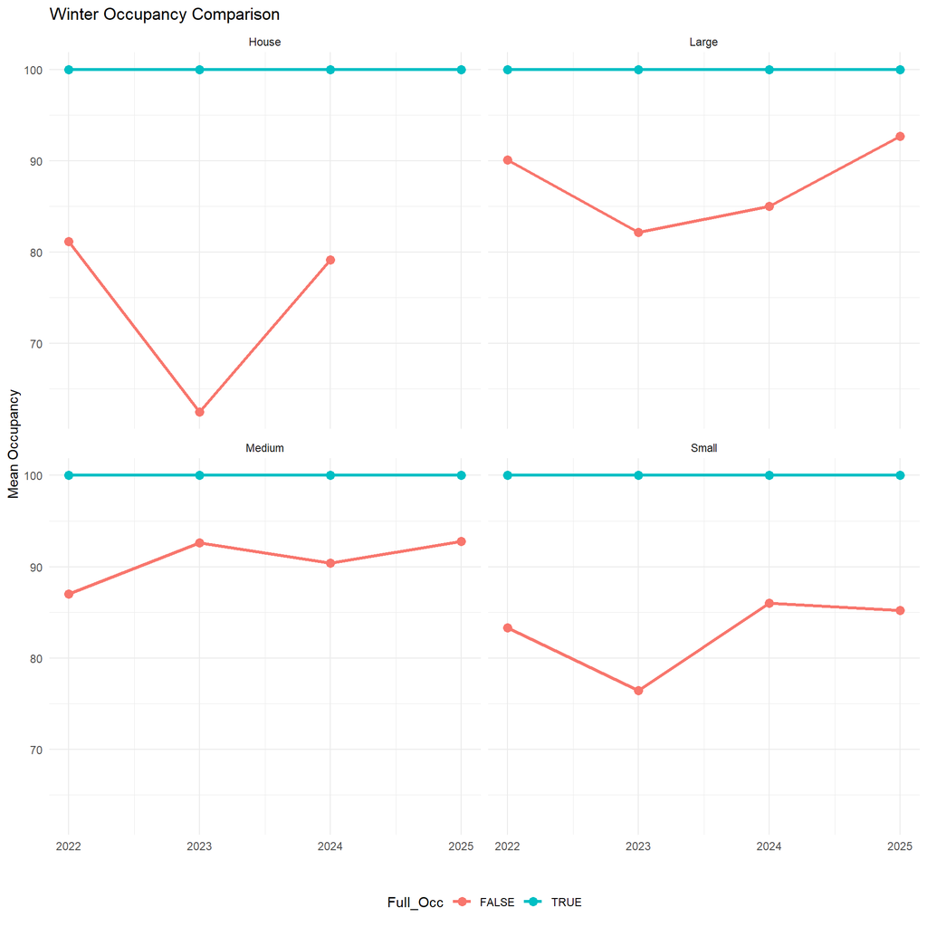

```r
occ_chart_winter <- ggplot(HSL_size_winter,
                      aes(x = Year, y = median_occ, color = Full_Occ)) +
  geom_line(linewidth = 1.2) +
  geom_point(size = 3) +
  facet_wrap(~property_size) +
  theme_minimal() +
  labs(
    y= "Mean Occupancy",
    x=" ",
    title="Winter Occupancy Comparison"
  ) +
  theme(
    legend.position = "bottom"
  )

occ_chart_winter
```

# Creating the New Variable

Here we want to determine the differences between properties that are full year-round, not-full year-round, full in winter but not spring, and full in spring but not winter.

We will start off by creating that variable titled “Year Occupancy Categories”.

```r
#lets start off by pivoting the table wider so that each property has only one row per year:

HSL_wide <- HSL_data |>
  select(Property, Year, Semester, boolocc) |>
  pivot_wider(names_from = Semester, values_from = boolocc) |>
  rename(occ_winter = WI, occ_spring = SP)
```

```r
#now we want to create the actual categorical variables:

HSL_wide <- HSL_wide |>
  mutate(Year_Occ_Category = case_when(
    occ_winter==1 & occ_spring == 1 ~"Full Year-Round",
    occ_winter==0 & occ_spring==0 ~"Not Full Year-Round",
    occ_winter==1 & occ_spring==0~ "Full Winter, Not Spring",
    occ_winter==0 & occ_spring==1 ~"Full Spring, Not Winter"
  ))
```

```r
#now I need to join this new variable onto the original dataset
HSL_data <- HSL_data |>
  left_join(HSL_wide |> select(Property, Year, Year_Occ_Category),
            by = c("Property","Year"))
```

```r
occ_summary <- HSL_data |>
  group_by(Year_Occ_Category) |>
  summarize(
    avg_occ_rate = mean(Occ_Rate, na.rm = TRUE),
    avg_price    = mean(Mean_Contract_Price, na.rm = TRUE),
    avg_bedcount    = mean(Total_Beds, na.rm = TRUE),
    avg_maintenance  = mean(Maintenance_Response, na.rm = TRUE),
    avg_cleanliness  = mean(Cleanliness, na.rm = TRUE),
    avg_culture  = mean(Culture, na.rm = TRUE),
    n_properties = n_distinct(Property),
    avg_culture  = mean(Culture, na.rm = TRUE),
    avg_activities = mean(Activities_Events, na.rm = TRUE),
    avg_management = mean(Management, na.rm = TRUE)
    ) |>
  filter(!is.na(Year_Occ_Category)) |>
  filter(Year_Occ_Category != "Full Spring, Not Winter")
```

```r
library(ggplot2)
library(plotly)

#to define consistent category colors
category_colors <- c(
  "Full Year-Round"        = "#006EB6",
  "Not Full Year-Round"    = "#949598",
  "Full Winter, Not Spring" = "#003865",
  "Full Spring, Not Winter" = "#72B5E0"
)


#helper function to keep styling consistent
make_chart <- function(data, y_var, y_label) {
  p <- ggplot(data, aes(x = Year_Occ_Category, y = .data[[y_var]], fill = Year_Occ_Category)) +
    geom_col() +
    scale_fill_manual(values = category_colors) +
    theme_minimal() +
    theme(
      plot.title    = element_text(size = 16, face = "bold"),
      axis.text.x   = element_text(angle = 20, hjust = 1),
      legend.position = "none"
    ) +
    labs(
      title = "Student Approved Housing 2022-2025",
      x     = "Occupancy Category",
      y     = y_label
    )
  ggplotly(p)
}

# Generate each chart
make_chart(occ_summary, "avg_occ_rate",    "Avg Occupancy Rate")
```

[interactive chart not shown]

```r
make_chart(occ_summary, "avg_price",        "Avg Contract Price")
```

[interactive chart not shown]

```r
make_chart(occ_summary, "avg_bedcount",     "Avg Total Beds")
```

[interactive chart not shown]

```r
make_chart(occ_summary, "avg_maintenance",  "Avg Maintenance Response")
```

[interactive chart not shown]

```r
make_chart(occ_summary, "avg_cleanliness",  "Avg Cleanliness")
```

[interactive chart not shown]

```r
make_chart(occ_summary, "avg_culture",      "Avg Culture")
```

[interactive chart not shown]

```r
make_chart(occ_summary, "avg_activities", "Avg Activities")
```

[interactive chart not shown]

```r
make_chart <- function(data, y_var, y_label) {
  p <- ggplot(data, aes(x = Year_Occ_Category, y = .data[[y_var]], color = Year_Occ_Category, group = 1)) +
    geom_line(size = 1.2, color = "#DDDDDD") +
    geom_point(size = 3) +
    scale_color_manual(values = category_colors) +
    theme_minimal() +
    theme(
      plot.title      = element_text(size = 16, face = "bold"),
      axis.text.x     = element_text(angle = 20, hjust = 1),
      legend.position = "none"
    ) +
    labs(
      title = "Student Approved Housing 2022-2025",
      x     = "Occupancy Category",
      y     = y_label
    )
  ggplotly(p)
}

# Generate each chart
make_chart(occ_summary, "avg_occ_rate",    "Average Occupancy Rate")
```

[interactive chart not shown]

```r
make_chart(occ_summary, "avg_price",        "Average Contract Price")
```

[interactive chart not shown]

```r
make_chart(occ_summary, "avg_bedcount",     "Average Total Beds")
```

[interactive chart not shown]

```r
make_chart(occ_summary, "avg_maintenance",  "Average Maintenance Response")
```

[interactive chart not shown]

```r
make_chart(occ_summary, "avg_cleanliness",  "Average Cleanliness")
```

[interactive chart not shown]

```r
make_chart(occ_summary, "avg_culture",      "Average Culture")
```

[interactive chart not shown]

```r
make_chart(occ_summary, "avg_activities",      "Average Activities")
```

[interactive chart not shown]

```r
make_chart(occ_summary, "avg_management", "Average Management")
```

[interactive chart not shown]

```r
# List of variables to test
variables <- c("Occ_Rate", "Mean_Contract_Price", "Total_Beds",
               "Maintenance_Response", "Cleanliness", "Culture", "Activities_Events", " Management")

# Run ANOVA for each variable
anova_results <- map(variables, function(var) {
  formula <- as.formula(paste(var, "~ Year_Occ_Category"))
  aov_result <- aov(formula, data = HSL_data)
  summary(aov_result)[[1]] |>
    rownames_to_column("Term") |>
    mutate(Variable = var)
}) |>
  bind_rows() |>
  filter(Term == "Year_Occ_Category") |>
  select(Variable, `F value`, `Pr(>F)`) |>
  mutate(
    Significant = ifelse(`Pr(>F)` < 0.05, "Yes", "No"),
    `Pr(>F)` = round(`Pr(>F)`, 4),
    `F value` = round(`F value`, 3)
  )

anova_results
```

[output not shown]

This analysis further supports the idea that the properties that tend to be the most competitive during the spring also tend to earn the highest maintenance, management, and cleanliness survey results from students. Also, those that tend to be competitive during the spring semester also tend to have lower activities and culture survey results than those whom are not competitive.

## Identifying Competitive Year-Round Properties

```r
full_year_round <- HSL_data |>
  filter(Year_Occ_Category == "Full Year-Round") |>
  select(Property, property_size, Gender) |>
  group_by(Property, Gender, property_size) |>
  summarise(
    count_full = count(Property)/2
  )

pander(table(full_year_round$property_size))
```

| House | Large | Medium | Small |
| --- | --- | --- | --- |
| 6 | 5 | 7 | 13 |

## Exploring Management Companies

```r
management_summary <- HSL_data |>
  group_by(Management_Name) |>
  summarize(
    avg_occ_rate = mean(Occ_Rate, na.rm = TRUE),
    avg_price    = mean(Mean_Contract_Price, na.rm = TRUE),
    avg_bedcount    = mean(Total_Beds, na.rm = TRUE),
    avg_maintenance  = mean(Maintenance_Response, na.rm = TRUE),
    avg_cleanliness  = mean(Cleanliness, na.rm = TRUE),
    avg_culture  = mean(Culture, na.rm = TRUE),
    n_properties = n_distinct(Property),
    avg_culture  = mean(Culture, na.rm = TRUE),
    avg_activities = mean(Activities_Events, na.rm = TRUE),
    avg_management = mean(Management, na.rm = TRUE)
    )
```

```r
make_chart <- function(data, y_var, y_label) {
  p <- ggplot(data, aes(x = Management_Name, y = .data[[y_var]], color = Management_Name, group = 1)) +
    geom_line(size = 1.2, color = "#DDDDDD") +
    geom_point(size = 3) +
    scale_color_manual(values = category_colors) +
    theme_minimal() +
    theme(
      plot.title      = element_text(size = 16, face = "bold"),
      axis.text.x     = element_text(angle = 20, hjust = 1),
      legend.position = "none"
    ) +
    labs(
      title = "Student Approved Housing 2022-2025",
      x     = "Management Company",
      y     = y_label
    )
  ggplotly(p)
}

# Generate each chart
make_chart(management_summary, "avg_occ_rate",    "Average Occupancy Rate")
```

[interactive chart not shown]

```r
make_chart(management_summary, "avg_price",        "Average Contract Price")
```

[interactive chart not shown]

```r
make_chart(management_summary, "avg_bedcount",     "Average Total Beds")
```

[interactive chart not shown]

```r
make_chart(management_summary, "avg_maintenance",  "Average Maintenance Response")
```

[interactive chart not shown]

```r
make_chart(management_summary, "avg_cleanliness",  "Average Cleanliness")
```

[interactive chart not shown]

```r
make_chart(management_summary, "avg_culture",      "Average Culture")
```

[interactive chart not shown]

```r
make_chart(management_summary, "avg_activities",      "Average Activities")
```

[interactive chart not shown]

```r
make_chart(management_summary, "avg_management", "Average Management")
```

[interactive chart not shown]

Back to top